# DV02_GIS_rmd.rmd

Pat Zhang

2023-04-18

#### ———————— Background —————————

Create GIS data viz for community Partners

#### ———————— Tasks —————————

1 - Meet with community partners to determine GIS needs  
2 - Prioritize tables that provide most value for most community partners  
3 - Create GIS data viz

#### ————————- Questions ————————–

#### ————————- April ’23 Sprint Notes ————————–

- What are some important community resources?  
  Durham PR: Look at all of our parks - 60ish parks. GPS data is available. Send Jason email for the park lat and long  
  NCCEH: Service providers - mostly shelters, but there are also some permanent housing fixures. A main address. In durham there are 3-5. Follow up, might be able to get lat long from CSCC  
  NCCEH - most useful is HIV, medically disabling condition, mental health diagnosis, substance use disorder  
  CH PR: Can we add greenways; add rec centers like aquatic facilities. Public recreational facilities - Private planet fitness centers, and 02 fitness centers  
  CH PR has participants from other counties
- May Enhancements: Add Inpatient hospitals for duke and UNC  
  Possibly look at schools. School system could be used for ppl to be active  
  YMCA: Branch locations - See if there is a association with program participants and if there. 4 branches

### ————————-Start Code ————————–

Import libraries

```r
library(stringr)
library(dplyr)
library(magrittr)
library(ggplot2)
theme_set(theme_bw())
library(sf)
library(readxl)
library(readr)
library(data.table)
library(tidycensus)
library(table1)
library(ggspatial)
library(ggrepel)
```

Set Variables Based on Local Directories

```r
## Define dataset directory location
source_data <- "C:/Users/rvy3/OneDrive - CDC/CDC_Work/PHIFP/Capstone/DMI_SQ_Capstone/Data/use case 1/UseCase1_prepped.csv"

## Import data
dat_raw <- fread(source_data) |>
  mutate("GEOID" = as.character(GEOID))


## Select relevant variables
## Data is given for every year 2017-2021 regardless of encounter or program enrollment

## Define columns to keep
vec_colnames <- colnames(dat_raw)
vec_keepcols <- vec_colnames[c(1:21, match(c("GEOID", "BMI", "BMI_cat"
                                             ),vec_colnames))]

dat <- dat_raw |>
  ## Get demographics of patient for year they enrolled in program
  filter(year_enroll == year) |>
  select(all_of(vec_keepcols))
```

GIS Data

Get ACS data

```r
### Make durham base map
durham_gis_base <- get_acs(
  state = "NC",
  county = "Durham",
  geography = "tract",
  variables = "B19013_001",
  geometry = TRUE,
  year = 2020
)
```

Get Durham data

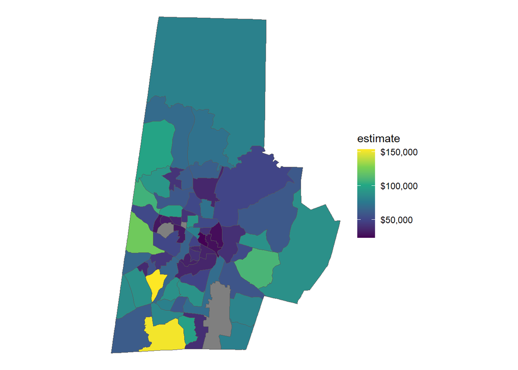

```r
durham_gis_base %>%
  ggplot(aes(fill = estimate)) +
  geom_sf() +
  theme_void() +
  scale_fill_viridis_c(labels = scales::dollar)
```

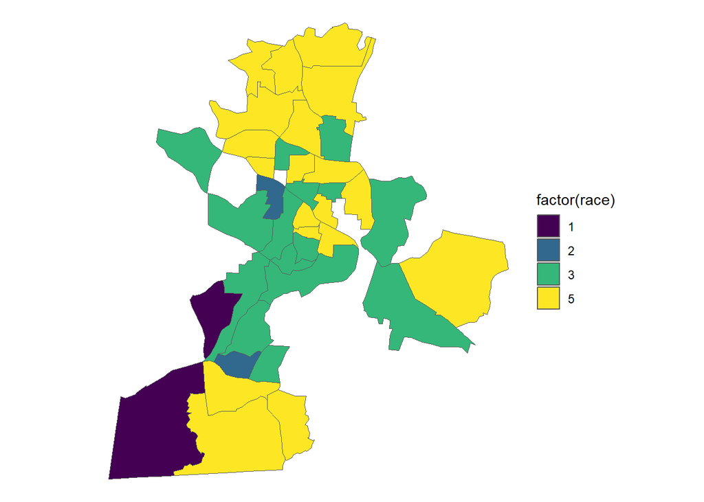

```r
## Merge location data with synthea data
## Left join causes an error for some reason, must use right for GIS

# synthea_GIS <- synthea_data_ctracts_raw |>
#   left_join(durham_gis_base, by = "GEOID")

synthea_GIS <- durham_gis_base |>
  right_join(dat, by = "GEOID", multiple= "all")

## Try plotting
synthea_GIS %>%
  ggplot(aes(fill = factor(race))) +
  geom_sf() +
  theme_void() +
  scale_fill_viridis_d()
```

#### Workflow for making maps

- Use synthea_data_ctracts_raw dataset as starting point.
- starting fields: select(GEOID, patid, …)
- Summarize to relevant information
- merge data into durham_gis_base
- Make the map

Map 1: Basic Map

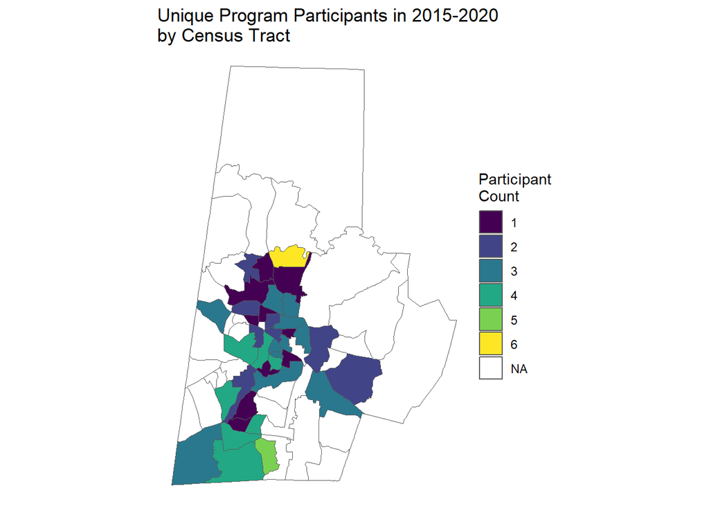

```r
## Among all program participants from 2015-2020, Count number of unique participants by census tract
patid_count_by_ctract  <- dat |>
  select(GEOID, patid, programid, completion_date1, enrollment_date1) |>
  distinct() |>
  group_by(GEOID) |>
  summarise(count_patid = n())
## Good

## Merge durham gis data
patid_count_by_ctract_b <- durham_gis_base |>
  left_join(patid_count_by_ctract, by = "GEOID")

## Map of participant count
patid_count_by_ctract_b %>%
  ggplot(aes(fill = factor(count_patid))) +
  geom_sf() +
  theme_void() +
  scale_fill_viridis_d("Participant\nCount") +
  labs(
    title = "Unique Program Participants in 2015-2020\nby Census Tract"
  )
```

Map 2: Map of patients with overweight obesity

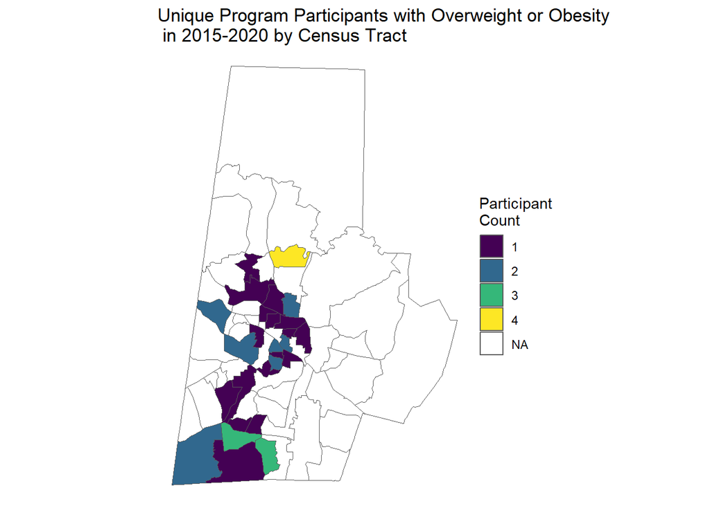

```r
## Filter to patients the year they joined the program
patid_count_ow_obes_a  <- dat |>
  select(GEOID, patid, programid, completion_date1, enrollment_date1, year_enroll, year, BMI) |>
  ## Get demographics of patient for year they enrolled in program
  filter(year_enroll == year) |>
  distinct() |>
  filter(BMI >= 25) |>
  ### Summarise by census tract
  group_by(GEOID) |>
  summarise(count_patid = n())

## Merge durham gis data
patid_count_ow_obes_b <- durham_gis_base |>
  left_join(patid_count_ow_obes_a, by = "GEOID")

## Map of overweight or obesity counts
patid_count_ow_obes_b %>%
  ggplot(aes(fill = factor(count_patid))) +
  geom_sf() +
  theme_void() +
  scale_fill_viridis_d("Participant\nCount") +
  labs(
    title = "Unique Program Participants with Overweight or Obesity \n in 2015-2020 by Census Tract"
  )
```

Map 3: Map with field sites - Helpful link: https://r-spatial.org/r/2018/10/25/ggplot2-sf-2.html

```r
### Define field sites
## Park Sites - Duke Gardens, Lakewood YMCA, CM Heardon Park
park_sites_input <- data.frame(longitude = c(-78.93062814585198, -78.92875947601084, -78.93428039035894),
                    latitude = c(36.00233152427145, 35.9857657152483, 35.88037247132986))
(park_sites <- st_as_sf(park_sites_input, coords = c("longitude", "latitude"),
                   crs = 4326, agr = "constant"))
```

```
## Simple feature collection with 3 features and 0 fields
## Geometry type: POINT
## Dimension:     XY
## Bounding box:  xmin: -78.93428 ymin: 35.88037 xmax: -78.92876 ymax: 36.00233
## Geodetic CRS:  WGS 84
##                     geometry
## 1 POINT (-78.93063 36.00233)
## 2 POINT (-78.92876 35.98577)
## 3 POINT (-78.93428 35.88037)
```

```r
## Shelter Sites - Durham Rescue Mission
shelter_sites_input <- data.frame(longitude = c(-78.88545765708044),
                               latitude = c(36.013493602580965))
(shelter_sites <- st_as_sf(shelter_sites_input, coords = c("longitude", "latitude"),
                        crs = 4326, agr = "constant"))
```

```
## Simple feature collection with 1 feature and 0 fields
## Geometry type: POINT
## Dimension:     XY
## Bounding box:  xmin: -78.88546 ymin: 36.01349 xmax: -78.88546 ymax: 36.01349
## Geodetic CRS:  WGS 84
##                     geometry
## 1 POINT (-78.88546 36.01349)
```

```r
## Clinical Sites - Duke Univ hospital, Duke Regional Hospital
clinical_sites_input <-  data.frame(longitude = c(-78.93797806516106, -78.89646435804023),
                              latitude = c(36.008173476824105, 36.039183491500786))
(clinical_sites <- st_as_sf(clinical_sites_input, coords = c("longitude", "latitude"),
                             crs = 4326, agr = "constant"))
```

```
## Simple feature collection with 2 features and 0 fields
## Geometry type: POINT
## Dimension:     XY
## Bounding box:  xmin: -78.93798 ymin: 36.00817 xmax: -78.89646 ymax: 36.03918
## Geodetic CRS:  WGS 84
##                     geometry
## 1 POINT (-78.93798 36.00817)
## 2 POINT (-78.89646 36.03918)
```

```r
## Durham city
durham_cities_input <- data.frame(city = c("Durham (city)"), Latitude = c(35.99285703980655), Longitude = c(-78.89727488007892))

(durham_cities <- st_as_sf(durham_cities_input, coords = c("Longitude", "Latitude"), remove = FALSE, crs = 4326, agr = "constant"))
```

```
## Simple feature collection with 1 feature and 3 fields
## Attribute-geometry relationship: 3 constant, 0 aggregate, 0 identity
## Geometry type: POINT
## Dimension:     XY
## Bounding box:  xmin: -78.89727 ymin: 35.99286 xmax: -78.89727 ymax: 35.99286
## Geodetic CRS:  WGS 84
##            city Latitude Longitude                   geometry
## 1 Durham (city) 35.99286 -78.89727 POINT (-78.89727 35.99286)
```

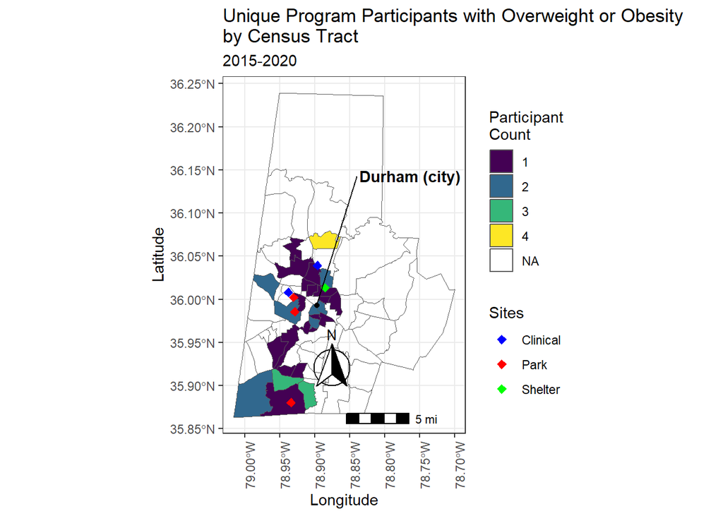

```r
# (durham_cities <- st_as_sf(durham_cities_input, coords = c("longitude", "latitude"), crs = 4326, agr = "constant"))

# colors to mark the points
color_park = "red"
color_clinical = "blue"
color_shelter = "green"
cols.sol = c("Park" = color_park, "Clinical" = color_clinical, "Shelter" = color_shelter)

## Plot on map
# patid_count_by_ctract_b |> ###### This is uni participants total
patid_count_ow_obes_b %>%  #### This is uni participants with obes
  ggplot(aes(fill = factor(count_patid))) +
  geom_sf() +
  ## Add coordinate site points
  geom_sf(data = clinical_sites, size = 2, shape = 23, inherit.aes = F, fill = "blue", aes(color = 'Clinical')) +
  geom_sf(data = park_sites, size = 2, shape = 23, inherit.aes = F, fill = "red", aes(color = 'Park')) +
  geom_sf(data = shelter_sites, size = 2, shape = 23, inherit.aes = F, fill = "green", aes(color = 'Shelter')) +

  ## Add durham city
  geom_sf(data = durham_cities, inherit.aes = F) +
  geom_text_repel(data = durham_cities, aes(x = Longitude, y = Latitude, label = city),
                  inherit.aes = F,
                  fontface = "bold", nudge_x = c(.15), nudge_y = c(0.15)) +

  ## Rotate x axis text by 90 degrees
  theme(axis.text.x = element_text(angle = 90)) +

  scale_fill_viridis_d("Participant\nCount") +
  ## Add scale for points
  scale_colour_manual(name = "Sites",
                      values = cols.sol,
                      # guide = guide_legend(override.aes = list(shape = c(23, 23)))) +
                      guide = guide_legend(override.aes = list(linetype = c("blank", "blank", "blank"),
                                                               fill = c("blue", "red", "green"),
                                                                 shape = c(23, 23, 23)))) +

  ## Add title
  ggtitle("Unique Program Participants with Overweight or Obesity\nby Census Tract", subtitle = "2015-2020") +
  # ggtitle("Unique Program Participants by Census Tract", subtitle = "2015-2020") +
  ## Add compass and map scale
  annotation_scale(location = "bl", width_hint = .3, pad_x = unit(1.2, "in"), unit_category = "imperial") +
  annotation_north_arrow(location = "br", which_north = "true",
                         pad_x = unit(1, "in"), pad_y = unit(0.4, "in"),
                         style = north_arrow_fancy_orienteering)
```